# Text Similarity

Introduction to Text as Data

Amber Boydstun & Cory Struthers

January 25-27, 2024

### Introduction

A number of approaches to text similarity exist, but we’ll focus pairwise comparisons. “Pairwise” means that the terms of each document (or group of documents) in the corpus are compared to the terms of every other document (or group of documents) in the corpus.

Pairwise comparison is a “bag of words” approach, meaning the frequency of terms influence the output but the order of the terms do not.

We will need the following packages:

```r
library(quanteda)
library(quanteda.textstats)
library(tidyverse)
library(ggplot2)
library(ggdendro)
library(comperes)
library(readxl)
library(igraph)
library(tidytext)
library(grid) # additional package! (for figure)
library(gridExtra) # additional package! (for figure)

options("scipen"=100, "digits"=4)

# Set working directory
setwd("~/Dropbox/text-as-data-JUST-CORY-AND-AMBER/modules_2024/data/")
getwd() # view working directory
```

Most text similarity methods are vector space models, which use linear algebra to more directly leverage word counts to represent meaningful differences (or lack thereof) between two or more texts.

Unlike dictionary methods, which count the only terms the researcher designates, text similarity uses *all terms* in a vector (i.e., the document converted to a row in a dfm) to evaluate similarity.

For this reason, crafting the dfm carefully in the pre-processing stage is essential.

`quanteda` offers two functions related to text (dis)similarity. Both return a *D* x *D* symmetrical matrix, where *D* is equal to the number of documents (however grouped) in the corpus, and each cell represents the similarity or distance between two text vectors.

Let’s begin with a toy example, completing pre-processing steps as usual. Note that removing stopwords are particularly important in text similarity approaches because stopwords will drive similarity between texts despite being conceptually meaningless.

```r
# Toy example
energy = c(position1 = "We must adapt our energy infrastructure to climate change.",
            position2 = "Low income people are harmed by renewable energy commitments.",
            position3 = "Health and climate benefits are core factors in determining energy policy.",
            position4 = "Energy policy should prioritize keeping electricty prices low for people.")

# Construct dfm
energy_dfm = corpus(energy) %>%
    quanteda::tokens(remove_punct = TRUE) %>% # specify quanteda because tidytext loaded
    tokens_remove(stopwords("en"))  %>%
    tokens_wordstem() %>%
    dfm()
energy_dfm
```

### Apply Euclidean distance

The Euclidean distance between two vectors, *a* and *b*, is calculated as:

$\boldsymbol{a} - \boldsymbol{b} = \sqrt{(\sum^n_1{(a_i-b_i)^2}}$

Euclidean distance ranges from 0 to values greater than 1. Larger values indicate greater distance, or less similarity, while smaller values mean less distance, or greater similarity.

Below, we apply the calculation from the `textstat_dist` function. `textstat_dist` calculates the *distance* between two vectors, applying `euclidean`, `Chisquared`, `minkowski`, or other methods as options the researcher specifies. `euclidean` is the most common and the default method for `textstat_dist()`.

After applying `textstat_dist`, we’ll calculate pairwise comparisons “by hand” to improve our understanding of this pairwise approach.

```r
# Euclidean distance quanteda function
energy_dist = textstat_dist(energy_dfm , method = "euclidean") # default
print(energy_dist)

# First, reshape dfm object so columns are each text and rows are features
energy_dfm_reshaped = tidy(energy_dfm) %>% # using tidytext
  cast_dfm(term, document, count)  %>% # using tidytext
  convert("data.frame")

# Euclidean distance calculation
euclidean_dist = function(a,b) sqrt(sum((a - b)^2))

# Apply to lowest and highest observed distances
euclidean_dist(energy_dfm_reshaped$position2, energy_dfm_reshaped$position4) # least distant (lowest value)
euclidean_dist(energy_dfm_reshaped$position2, energy_dfm_reshaped$position3) # most distant (highest value)
```

[output not shown]

Let’s refresh our memories of the text in position2 and position4:

```r
energy[2]
energy[4]
```

### Apply cosine similarity

Now let’s do apply cosine similarity using `textstat_simil`. The cosine similarity of two vectors, A and B, is calculated as:

Cosine similarity = $\frac{ \boldsymbol{a}}{|| \boldsymbol{a}||}.\frac{ \boldsymbol{b}}{|| \boldsymbol{b}||} = \frac{\sum_ia_ib_i}{(\sqrt{\sum_ia^2_i}(\sqrt{\sum_ib^2_i}}$

Cosine similarity scores range from 0 to 1. The inverse of Euclidean distance, larger values in cosine similarity indicate greater *similarity*, or less distance, while smaller values mean less similarly, or greater distance.

Methods options for `textstat_simil` include `cosine`, `correlation`, `jaccard`, among others. `cosine` is the default and currently the most popular.

```r
# Cosine similarity quanteda function
energy_simil = textstat_simil(energy_dfm, method="cosine")
print(energy_simil)

# Cosine similarly calculation
cosine_sim = function(a, b) {
  return(sum(a*b)/sqrt(sum(a^2)*sum(b^2)) )
}

# Again, using reshaped dfm
cosine_sim(energy_dfm_reshaped$position2, energy_dfm_reshaped$position4)
cosine_sim(energy_dfm_reshaped$position2, energy_dfm_reshaped$position3)
```

[output not shown]

Now, let’s imagine that a researcher had asked respondents to describe their position on energy policy in an open-ended survey question, and wants to understand whether individual attributes (ideology, class) shape similarity among responses.

One reason cosine similarity is usually used over Euclidean distance for larger corpora is the former normalizes for magnitude, or document length, by comparing the angle of the vectors.

Let’s experiment with our toy example to see what happens when we make position4 a much longer document.

```r
# Experimental example
energy_exp = c(position1 = "We must adapt our energy infrastructure to climate change.",
            position2 = "Low income people are harmed by renewable energy commitments.",
            position3 = "Health and climate benefits are core factors in determining energy policy.",
            position4 = "Energy policy should prioritize keeping electricty prices low for people. The rest of this text is substantively meaningless. Let's see what happens to our measures when we have a really long document compared to the rest of the documents.")

# Construct dfm
exp_dfm = corpus(energy_exp) %>%
    quanteda::tokens(remove_punct = TRUE) %>%
    tokens_remove(stopwords("en"))  %>%
    tokens_wordstem() %>%
    dfm()

# Apply Euclidean distance
exp_dist = textstat_dist(exp_dfm, method = "euclidean")
print(exp_dist)
```

[output not shown]

Let’s try cosine similarity, which normalizes for document length.

```r
# Apply cosine similarity
exp_simil = textstat_simil(exp_dfm, method="cosine")
print(exp_simil)
```

[output not shown]

### Visualization through hierarchical clustering

Now let’s try each of these tools on a larger corpus. Like always, we first tokenize and convert the text to a dfm. Below, we use the news corpus, first applying collocation analysis to identify common capitalized bi- and tri-grams, and then adding them to the tokens object.

Importantly, and depending on the research question and data, TF-IDF weights are appropriate or preferred to unweighted term counts in the dfm. For simplicity, we stick with unweighted term counts in our example.

```r
# load news corpus
news_corp = readRDS("news_corp.RDS")

# Create tokens object
news_toks = news_corp %>%
    quanteda::tokens(remove_punct = TRUE,
           remove_numbers = TRUE,
           remove_symbols = TRUE) %>%
  tokens_remove(pattern = stopwords("en")) # remove stopwords in tokens

# Identify capitalized collocations
news_cols = tokens_select(news_toks, pattern = "^[A-Z]",
                                valuetype = "regex",
                                case_insensitive = FALSE) %>%
                  textstat_collocations(min_count = 10, size=2:3) # specify size
head(news_cols, 20)

# Incorporate collocations into dfm toks
news_dfm =  tokens_compound(news_toks, news_cols, concatenator = " ") %>%
    tokens_wordstem () %>% # stem words after adding collocations
    dfm(tolower = TRUE)  %>%
    dfm_trim(min_termfreq = 10, min_docfreq = 10)

# Observe collocations ("united st")
textstat_frequency(news_dfm) %>%
  head(50)
```

Conceivably, we might be interested in whether stories produced by similar outlets utilize more or less similar terms. We can group our dfm by “Source” to explore support for this premise. Like we’ve done in prior modules, we can group the dfm by source and then use `textstat_dist` to first compare the pairwise euclidean distance of the 14 sources in our corpus.

`quanteda` offers an option for easy and useful visualization of distance scores, particularly when grouped. After grouping the dfm and calculating euclidean distance across all pairs, we can visualize similarity scores across texts by different news sources using `hclust`, which is part of base R. `hclust` conducts hierarchical cluster analysis on the (dis)similiarities of the objects (in our case, texts by different media sources). As shown below, we add the `dist` function to convert the object to an object compatible with `hclust` to create the dendrogram.

```r
# Group dfm by news Source
news_dfm_sources = dfm_group(news_dfm, groups = Source)
ndoc(news_dfm_sources) # 14 groups

# Euclidean distance quanteda function
news_dist = as.dist(textstat_dist(news_dfm_sources, method = "euclidean"))
print(news_dist)

# Apply cluster analysis
news_source_clust = hclust(news_dist)
```

`ggdendrogram` in the `ggdendro` package will plot clusters from the `textstat_dist` matrix. A dendrogram is a tree diagram representing clustered observations, where “leaves” (the vertical, terminal lines) are nested in a branch (or clade, the horizontal lines). Both branches (the sub-organizational structure) and leaves (the magnitude) provide visual aid to clustering tendencies in the data. Separate branches indicate distinct clusters, and – for dissimilarity score – the higher the branch, the more dissimilar the clusters. Likewise, the taller the leaves, the more dissimilar the scores among that clustered group.

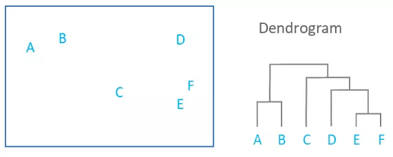

Note that the left-right orientation is irrelevant and that dendrograms cannot tell us how many clusters exist in the data.

```r
# Plot dendrogram
ggdendrogram(news_source_clust, rotate = TRUE) +
  labs( xlab="Distance", title="Dendrogram of News Articles by Source, Euclidean Distance")
```

[output not shown]

Although top features do not paint the full picture, they can give us some intuition of the terms driving distance (or similarity) among units. Let’s plot the top 15 terms by source.

```r
# Sort by reverse frequency order
freq_sources = textstat_frequency(news_dfm_sources, n = 15,
                                  groups = news_dfm_sources$Source)

# Plot
ggplot(data = freq_sources , aes(x = nrow(freq_sources):1, y = frequency)) +
     geom_point() +
     theme(text = element_text(size=24)) +
     facet_wrap(~ group, scales = "free") +
     coord_flip() +
     theme_classic() +
     scale_x_continuous(breaks = nrow(freq_sources):1,
                        labels = freq_sources$feature) +
     labs(x = NULL, y = "Relative frequency")
```

[output not shown]

Now let’s try applying cosine similarity to the corpus. A common practice among researchers is to convert cosine similarity scores to “cosine dissimilarity”, which can be done by subtracting the cosine similarity scores from 1. We’ll do that below in order to compare our two dendrograms using the `apply` function on the matrix object, then converting back to `dist` and `hclust`.

Apply functions are a family of functions in base R, which allow us to perform actions on many chunks of data. An apply function is a loop, but it runs faster than loops and often with less code. And, there are different apply() functions.

Note that the `dist` function does not change the values in the output, but makes the object compatible with `hclust`.

```r
# Cosine similarity quanteda function
news_source_cos_sim = as.dist(textstat_simil(news_dfm_sources, method = "cosine", margin="documents"))
print(news_source_cos_sim)

# Create matrix to transform
news_source_cos_sim = as.matrix(news_source_cos_sim)

# Flip output in each matrix cell and create hclust of distance
news_source_cos_dist_clust = hclust(as.dist(apply(news_source_cos_sim, 1, function(x) 1 - x)))

# Plot
ggdendrogram(news_source_cos_dist_clust, rotate = TRUE) +
  labs( xlab="Similarity", title="Dendrogram of News Articles by Source, Cosine Dissimilarity")
```

[output not shown]

```r
# Term count
rowSums(news_dfm_sources, -1)
```

[output not shown]

We should also consider other sources of variation across texts, that may be obscuring similarity or difference across sources. One obvious source of variation is article topic.

We can further distinguish groups to make source-topic comparisons.

```r
# Add "keyword"
news_dfm_sources_issue = dfm_group(news_dfm, groups = interaction(Source, keyword))
ndoc(news_dfm_sources_issue) # 79 groups

# Cosine similarity
news_source_issue_cos_sim = textstat_simil(news_dfm_sources_issue, method = "cosine", margin="documents")
```

Now let’s compare similarity across sources on two topics. We might expect tobacco to be a much less controversial and topic than same sex marriage, where views across media sources are likely more diverse and polarized.

To explore support for this expectation, we’d first subset the two topics from the larger source-topic dataframe.

```r
# Create df to subset
news_source_issue_cos_sim = as.data.frame(as.matrix(news_source_issue_cos_sim))

# Use grepl to subset to two issues
cos_sim_ss_marriage = news_source_issue_cos_sim[,grepl( "samesex" , names(news_source_issue_cos_sim) ) ]
cos_sim_ss_marriage = cos_sim_ss_marriage  %>%
  filter(grepl("samesex", rownames(cos_sim_ss_marriage)))

cos_sim_tob = news_source_issue_cos_sim[,grepl( "tobacco" , names(news_source_issue_cos_sim) ) ]
cos_sim_tob = cos_sim_tob  %>%
  filter(grepl("tobacco", rownames(cos_sim_tob)))
```

Now we can transform similarity matrices to pairs in order to compare average pairwise similarity scores between the two topics.

We do thi first for tobacco:

```r
# First transform tobacco matrix to pairs
cos_sim_tob = as.matrix(cos_sim_tob)
all_pairs_tob = as_long_data_frame(graph_from_adjacency_matrix(cos_sim_tob, weighted = TRUE, diag = FALSE, mode = "upper"))
all_pairs_tob = all_pairs_tob[3:5]
colnames(all_pairs_tob) = c("similarity", "source_keyword1", "source_keyword2")
head(all_pairs_tob)

# Average similarity across all tobacco pairs
mean(all_pairs_tob$similarity)
median(all_pairs_tob$similarity)
```

[output not shown]

And then for same-sex marriage:

```r
# Same steps for same-sex marriage
cos_sim_ss_marriage = as.matrix(cos_sim_ss_marriage)
all_pairs_ss = as_long_data_frame(graph_from_adjacency_matrix(cos_sim_ss_marriage, weighted = TRUE, diag = FALSE, mode = "upper"))
all_pairs_ss = all_pairs_ss[3:5]
colnames(all_pairs_ss) = c("similarity", "source_keyword1", "source_keyword2")
head(all_pairs_ss)

# Average
mean(all_pairs_ss$similarity)
median(all_pairs_ss$similarity)
```

[output not shown]

Finally, we can compare distributions and run a t-test to evaluate statistical significance.

```r
p1 = ggplot(all_pairs_tob, aes(x=similarity)) +
    geom_density() +
    ggtitle("Similarity, Tobacco Sources") +
    xlim(0,1)

p2 = ggplot(all_pairs_ss, aes(x=similarity)) +
    geom_density() +
    ggtitle("Similarity, Same-Sex Sources") +
    xlim(0,1)

grid.arrange(p1, p2, ncol=2)

t.test(all_pairs_tob$similarity, all_pairs_ss$similarity)
```

[output not shown]

### Homework

#### Discussion Question:

See question 4 below.

#### Coding Question:

1. Upload the immigration corpus once more.
2. Calculate cosine similarity by year (hint: you can use some of the code from yesterday).
3. Create a pairwise list of scores by year.
4. Examine cosine similarity scores by year. Why are the scores so much higher for this corpus than the one we used in class?
5. Create a new dfm, keeping stopwords. What happens to the similarity scores?